# PA1_template

Jie_Ren

16/02/2018

**Default setting**

```r
knitr::opts_chunk$set(
  message = FALSE,
  warning = FALSE,
  echo=TRUE,
  error = FALSE,
  fig.align = "center"
)

setwd("~/Desktop/5922/R")
library(ggplot2)
library(scales)
library(Hmisc)
library(gridExtra)
library(knitr)
```

## Loading and preprocessing the data

### 1. Reading in the dataset and/or processing the data

```r
activity <- read.csv("activity.csv", header = T)
# Remove na rows
activityona <- na.omit(activity)
activityona$date <- as.Date(activityona$date, format="%d/%m/%y")
```

## What is mean total number of steps taken per day?

### 1. Make a histogram of the total number of steps taken each day

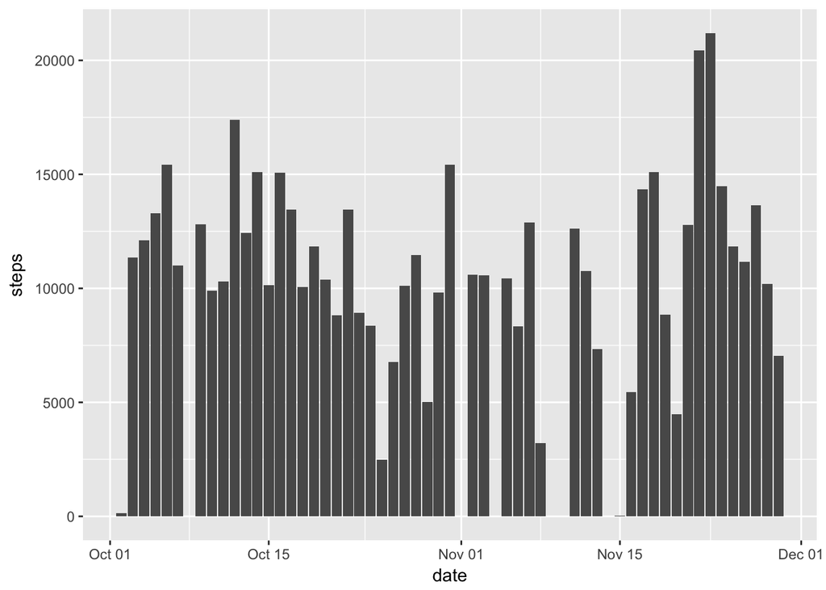

```r
# Calculate the total number of steps taken per day
activitysum <- aggregate(activityona["steps"], by=activityona["date"], sum)

# Make a histogram of the total number of steps taken each day
as <- ggplot(data = activitysum, aes(x = date, y = steps))
as + geom_bar(stat = "identity")
```

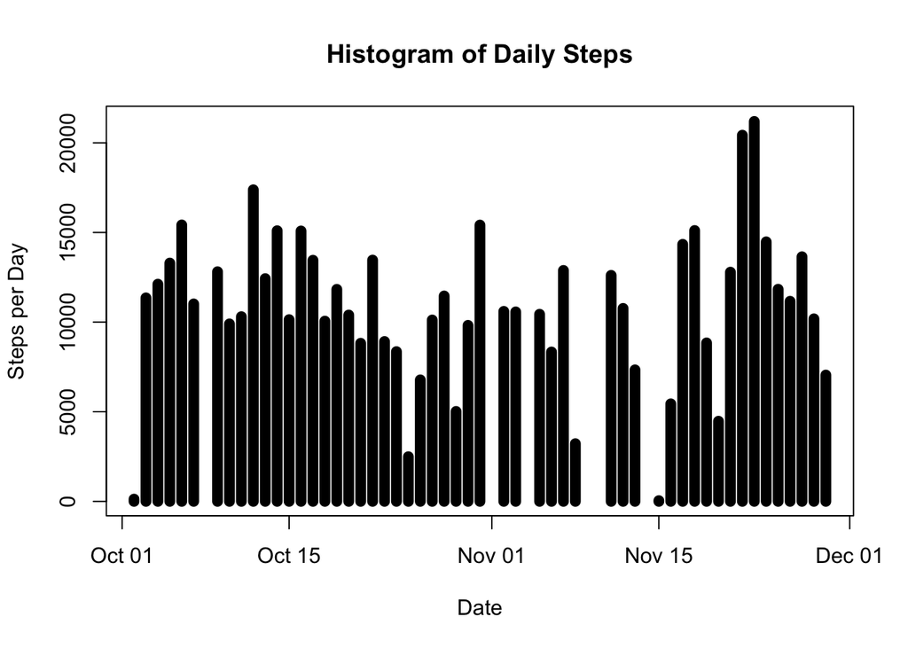

```r
# Method 1
plot(activitysum$date, activitysum$steps, type="h", main="Histogram of Daily Steps",xlab="Date", ylab="Steps per Day", col="black", lwd=8)
```

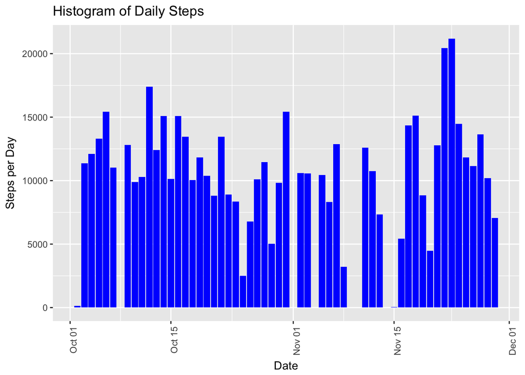

```r
# Method 2
ggplot(activitysum, aes(x=date, y=steps)) +
        geom_bar(stat="identity", fill = "blue") +
        ggtitle("Histogram of Daily Steps") +
        ylab("Steps per Day") +
        xlab("Date") +
        theme(axis.text.x = element_text(angle = 90, hjust = 1))
```

### 2. Calculate and report the mean and median total number of steps taken per day

```r
# Daily result
## Method 1
stepmedian<- aggregate(activityona["steps"], by=activityona["date"], median)
stepmean <- aggregate(activityona["steps"], by=activityona["date"], mean)
## Method 2
stepsummary <-aggregate(steps ~ date, data = activityona, summary)

# Total result
mean(activitysum$steps)
```

```
## [1] 10766.19
```

```r
median(activitysum$steps)
```

```
## [1] 10765
```

## What is the average daily activity pattern?

### 1. Time series plot of the average number of steps taken

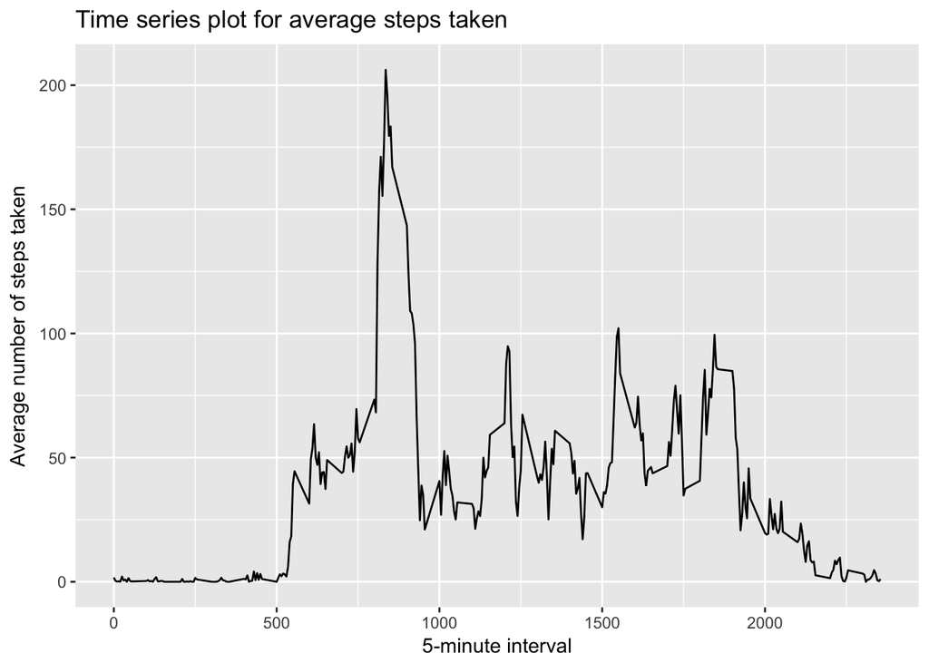

```r
activityave <- aggregate(x=list(meanSteps=activity$steps),
                                      by=list(interval=activity$interval), FUN=mean, na.rm=TRUE)
ggplot(activityave, aes(x = interval, y = meanSteps)) +
        geom_line() +
        ggtitle("Time series plot for average steps taken") +
        xlab("5-minute interval") +
        ylab("Average number of steps taken")
```

### 2. The 5-minute interval that, on average, contains the maximum number of steps

```r
MostSteps <- which.max(activityave$meanSteps)
cat("The row that contaisn maximum number of steps =",MostSteps)
```

```
## The row that contaisn maximum number of steps = 104
```

```r
timeMostSteps <-  gsub("([0-9]{1,2})([0-9]{2})", "\\1:\\2", activityave[MostSteps,'interval'])
cat("The time that contaisn maximum number of steps =",timeMostSteps)
```

```
## The time that contaisn maximum number of steps = 8:35
```

## Imputing missing values

### 1. Calculate and report the total number of missing values in the dataset

```r
# Method 1
nano1 <- sapply(activity, function(x) sum(is.na(x)))
# Method 2
nano2 <- sum(is.na(activity$steps))
cat("Total number of missing values in the dataset",nano2)
```

```
## Total number of missing values in the dataset 2304
```

The total number of missing values in the dataset is 2304 rows.

### 2. filling in all of the missing values in the dataset.

### 3. Create a new dataset that is equal to the original dataset but with the missing data filled in.

I decided to fill in all the NAs with the average value.

```r
imputed <- activity
imputed$steps <- impute(activity$steps, fun=mean)

# Test total number of missing value
cat("Test total number of missing values =",sum(is.na(imputed$imputed_steps)))
```

```
## Test total number of missing values = 0
```

### 4. Make a histogram of the total number of steps taken each day and Calculate and report the mean and median total number of steps taken per day.

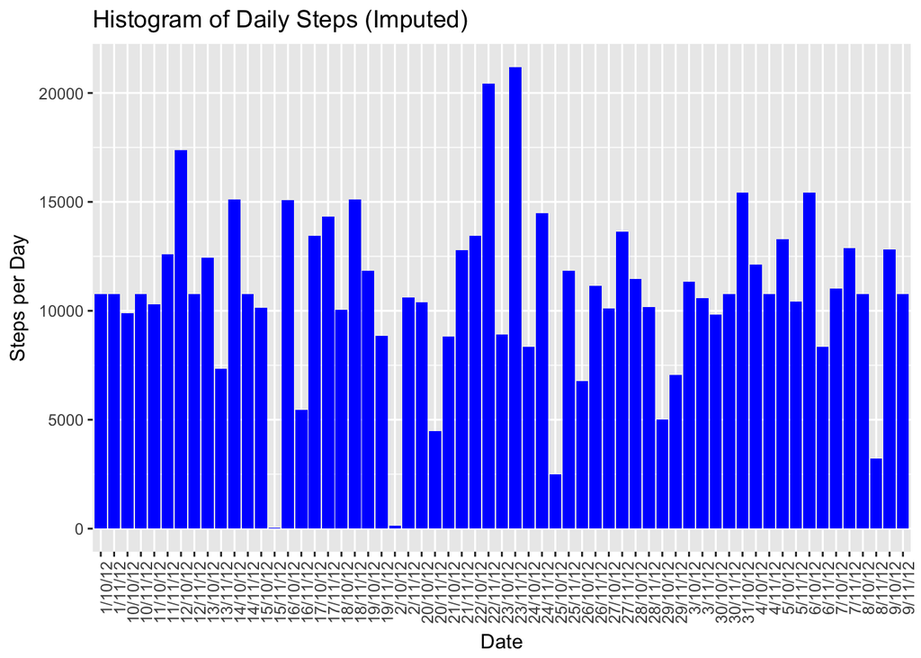

```r
imputedsum <- aggregate(imputed["steps"], by=imputed["date"], sum)
ggplot(imputedsum, aes(x=date, y=steps)) +
        geom_bar(stat="identity", fill = "blue") +
        ggtitle("Histogram of Daily Steps (Imputed)") +
        ylab("Steps per Day") +
        xlab("Date") +
        theme(axis.text.x = element_text(angle = 90, hjust = 1))
```

```r
mean(imputedsum$steps)
```

```
## [1] 10766.19
```

```r
median(imputedsum$steps)
```

```
## [1] 10766.19
```

**Do these values differ from the estimates from the first part of the assignment?** The mean is same as the previous part (10766.19). However, the median is now different. Previous median is 10765 and now changed to 10766.19.

**What is the impact of imputing missing data on the estimates of the total daily number of steps?** The distribution of histogram is changed.

## Are there differences in activity patterns between weekdays and weekends?

### 1. Create a new factor variable in the dataset with two levels – “weekday” and “weekend” indicating whether a given date is a weekday or weekend day.

```r
activityweek <- activityona
activityweek$weektime <- as.factor(ifelse(weekdays(activityona$date) %in% c("Saturday","Sunday"),"weekend", "weekday"))

Weekday <- subset(activityweek, weektime=="weekday")
Weekend <- subset(activityweek, weektime=="weekend")
```

### 2.Make a panel plot containing a time series plot (i.e. ) of the 5-minute interval (x-axis) and the average number of steps taken, averaged across all weekday days or weekend days (y-axis).

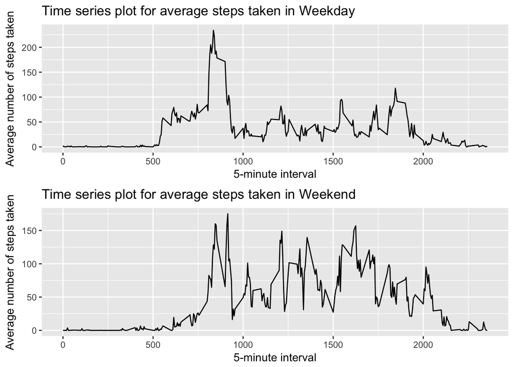

```r
# Weekday Histogram
Weekdayave <- aggregate(x=list(meanSteps=Weekday$steps),
                                      by=list(interval=Weekday$interval), FUN=mean, na.rm=TRUE)
WeekdayH <- ggplot(Weekdayave, aes(x = interval, y = meanSteps)) +
        geom_line() +
        ggtitle("Time series plot for average steps taken in Weekday") +
        xlab("5-minute interval") +
        ylab("Average number of steps taken")

# Weekend Histogram
Weekendave <- aggregate(x=list(meanSteps=Weekend$steps),
                                      by=list(interval=Weekend$interval), FUN=mean, na.rm=TRUE)
WeekendH <- ggplot(Weekendave, aes(x = interval, y = meanSteps)) +
        geom_line() +
        ggtitle("Time series plot for average steps taken in Weekend") +
        xlab("5-minute interval") +
        ylab("Average number of steps taken")

# Compare two time series together
grid.arrange(WeekdayH, WeekendH, nrow = 2)
```

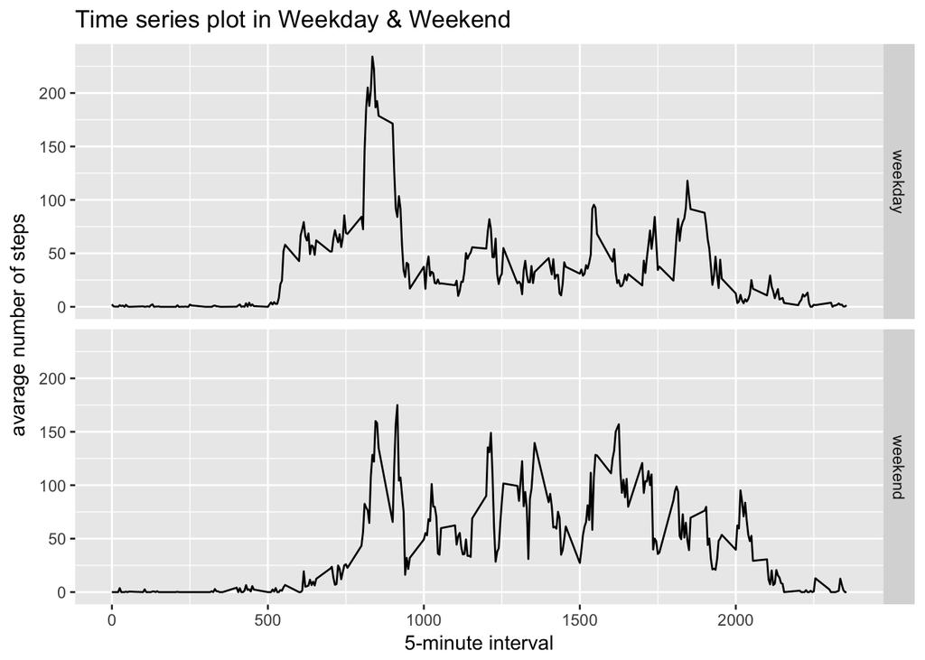

```r
# Method 2
activityweekave <- aggregate(steps ~ interval + weektime, data=activityweek, mean)
ggplot(activityweekave, aes(interval, steps)) +
        geom_line() +
        ggtitle("Time series plot in Weekday & Weekend") +
        facet_grid(weektime ~ .) +
        xlab("5-minute interval") +
        ylab("avarage number of steps")
```